# Belief disconfirmation versus habituation approaches to situational exposure in panic disorder with agoraphobia: A pilot study - ScienceDirect

[figure not shown]

## [Behaviour Research and Therapy](https://www.sciencedirect.com/journal/behaviour-research-and-therapy)

[Volume 45, Issue 5](https://www.sciencedirect.com/journal/behaviour-research-and-therapy/vol/45/issue/5), May 2007, Pages 877-885

# Belief disconfirmation versus habituation approaches to situational exposure in panic disorder with agoraphobia: A pilot study

[Paul M.Salkovskis](https://www.sciencedirect.com/science/article/pii/S0005796706000507?via%3Dihub#!)[AnnHackmann](https://www.sciencedirect.com/science/article/pii/S0005796706000507?via%3Dihub#!)[AdrianWells](https://www.sciencedirect.com/science/article/pii/S0005796706000507?via%3Dihub#!)[Michael G.Gelder](https://www.sciencedirect.com/science/article/pii/S0005796706000507?via%3Dihub#!)[David M.Clark](https://www.sciencedirect.com/science/article/pii/S0005796706000507?via%3Dihub#!)

https://doi.org/10.1016/j.brat.2006.02.008[Get rights and content](https://s100.copyright.com/AppDispatchServlet?publisherName=ELS&contentID=S0005796706000507&orderBeanReset=true)

## Abstract

Exposure therapy and cognitive behaviour therapy (CBT) are both effective in the treatment of panic disorder with agoraphobia. Cognitive theories suggest that the way in which exposure to avoided situations is implemented in either treatment may be crucial. In particular, it is suggested that clinical improvement will be greatest if opportunities for disconfirmation of feared catastrophes are maximized. In a small pilot study, 16 patients with panic disorder and (moderate or severe) agoraphobia were randomly allocated to either habituation based exposure therapy (HBET) or exposure planned as a belief disconfirmation strategy and accompanied by dropping of safety-seeking behaviours. Both treatments were brief (total of 3.25 h of exposure) and were similar in terms of expectancy of change. Patients in the CBT condition showed significantly greater improvements in self-report measures of anxiety, panic and situational avoidance. They also completed significantly more steps in a standardized behavioural walk, during which they experienced significantly less anxiety. The controlled effect sizes for CBT were substantial (range 1.7–2.7), which suggests it may be a particularly efficient way of managing therapeutic exposure to feared situations in panic disorder with agoraphobia. Further research is needed to clarify the mechanism of change involved.

## Keywords

Panic disorder

Agoraphobia

Cognitive behaviour therapy

Exposure therapy

Safety-seeking behaviours

Cognitive theory of panic disorder

## Introduction

It has long been known that exposure is a highly effective treatment for agoraphobic avoidance and situational fear (Mathews, Gelder, & Johnston, 1981). However, early studies indicated that 45% of patients suffering from panic disorder with agoraphobia continued to experience spontaneous panic attacks after 3 months of in vivo exposure (Michelson, Marchione, & Mavissakalian, 1985). The cognitive theory of panic (Clark (1986), Clark (1996)) proposes that panic attacks (both situational and non-situational) are a result of the person catastrophically misinterpreting bodily sensations, particularly those arising from anxiety. Safety-seeking behaviours (including both avoidance of agoraphobic situations and behaviours occurring within such situations and intended to prevent feared catastrophes) are said to be motivated by the catastrophic misinterpretations and to prevent belief change and clinical recovery (Clark, 1999; Salkovskis, 1991). If this is so, then situational exposure will be most beneficial when it helps the person to experience a disconfirmation of the catastrophic misinterpretations which occur within such situations. Although such disconfirmation may occur incidentally in the course of exposure, treatment should proceed most efficiently when patients have a framework which allows them to understand the role of misinterpretations in panic/anxiety and a set of procedures which allow them to generate convincing disconfirmations of their misinterpretations by dropping or reversing their safety-seeking behaviours in situations which normally provoke panic. The cognitive theory of panic and agoraphobia therefore predicts that the best results will be obtained in patients suffering from this disorder when the cognitive outcomes of behavioural change are maximised.

Williams and Falbo (1996) found that both exposure therapy and conventional cognitive restructuring gave poorer results in panic disorder patients with high levels of agoraphobic avoidance compared to panic disorder patients in whom avoidance is lower. When treatments specifically focussed on helping patients to deal with panic attacks have been evaluated, comparable reductions in panic frequency have generally been noted in patients with high and low levels of agoraphobic avoidance (Clark et al. (1994), Clark et al. (1999); Craske, DeCola, Sachs, & Pontillo, 2003; Hoffart, 1995).

There is some specific evidence consistent with the cognitive account of the link between threat beliefs, safety-seeking behaviours and the maintenance of phobic anxiety. Salkovskis, Clark, and Gelder, (1996) found systematic, theoretically predicted, associations between catastrophic beliefs and particular safety-seeking behaviours in a large sample of patients suffering from panic disorder. For example, an association was found between fears of passing out and holding onto people or objects. This fear was not associated with trying to do more exercise, whilst fears of being paralysed were. In an experimental study, eight patients suffering from social phobia were allocated in counterbalanced order to a session of exposure with an habituation rationale and no instructions regarding safety-seeking behaviours, and a session of exposure in which a cognitive rationale was offered as a way of getting participants to systematically decrease their safety seeking during the situational exposure. It was found that exposure combined with the cognitive rationale and decreased safety behaviours was significantly better than exposure with the habituation rationale in terms of reductions of within-situation anxiety and belief in the particular catastrophe that the patient feared (Wells et al., 1995).

In an experimental study of patients suffering from panic disorder with mainly severe agoraphobia similar effects were demonstrated (Salkovskis, Clark, Hackmann, Wells, & Gelder, 1999). All patients in that study carried out an initial behaviour test, closely followed by an experimental session, which included a brief (15 min) period of exposure during which participants either decreased or maintained within-situation safety-seeking behaviours. When the behaviour test was repeated within 2 days, patients who had decreased their safety-seeking behaviours during the experimental session showed a significantly greater reduction in catastrophic beliefs and anxiety than those who had maintained their safety-seeking behaviour. In both the Wells et al. (1995) and the Salkovskis et al. (1999) studies, the periods of exposure were very brief (15 min). The exposure used in exposure therapy treatment trials is usually of considerably longer duration (2–3 h), so it could be argued that the very brief exposure times used in these studies may have specifically disadvantaged the exposure condition. Typically, exposure is believed to require repeated and longer sessions in order to be effective in reducing anxiety (e.g. 24 h in the study by Michelson, Marchione, & Greenwald, 1996).

## Method

### Participants

Most participants were patients drawn from referrals for treatment of panic disorder and agoraphobia to a Health Service Psychiatric Outpatient Department and a Department of Clinical Psychology; some referrals came directly from general practitioners. Patients were admitted to the study if they fulfilled the following criteria: (i) DSM-IIIR (American Psychiatric Association, 1987) diagnosis of panic disorder with moderate or severe agoraphobic avoidance; (ii) at least two panic attacks occurring in the 4 weeks prior to assessment; (iii) a score of 9 or more on the modified Fear Questionnaire, agoraphobic avoidance subscale (Clark et al., 1994; maximum score on this scale is 15); (iv) inability to complete the penultimate step of a standardised behavioural avoidance test (see below); (v) identifiable catastrophic thoughts occurring during panic attacks, and (vi) safety-seeking behaviours which the patients said they carried out during the attacks to prevent the feared catastrophes. (One patient was excluded on the basis of failure to meet criterion (iv), and none on the basis of failure to meet (v) and (vi)). In addition, it was required that the patient rated an increase of anxiety from baseline of at least 20 points on a 100 point visual analogue scale when undergoing an individualised behaviour test for 5 min. Patients in the present study were drawn from those who participated in an earlier study of safety-seeking behaviour (Salkovskis et al., 1999) with two omissions. One patient completed the experimental session in Salkovskis et al. (1999) before the protocol for the present, extended exposure study was finalised. A second patient requested to be withdrawn from the study at the end of the first part.

Table 1. Means and standard deviations for main measures by group

| Empty Cell | BAI | Agoraphobic avoidance | Panic freq (0–15) | Agoraphobic cognitions freq (0–4) | Agoraphobic cognitions belief (0-**) | Behavioural walk: steps | Behavioural walk: peak anxiety | BDI | Credibility rating |
| --- | --- | --- | --- | --- | --- | --- | --- | --- | --- |
| *Cognitive-behavioural therapy* (CBT) |  |  |  |  |  |  |  |  |  |
| Pretreatment: | 39 | 11.1 | 2.9 | 38.5 | 537 | 3.1 | 90 | 19.9 | 87.5 |
| (SD) | (4.5) | (13.9) | (3.3) | (8.3) | (203) | (2.1) | (9.6) | (10.6) | (11.6) |
| Post-treatment | 11.1 | 4.2 | 0.5 | 17.7 | 48 | 9.2 | 38 | 7.4 |  |
| (SD) | (9) | (3.8) | (0.8) | (7.7) | (76) | (2.7) | (27) | (6.4) |  |
| *Habituation based behaviour therapy* (HBBT) |  |  |  |  |  |  |  |  |  |
| Pre-treatment | 34 | 13.5 | 3.0 | 45.2 | 650 | 2.7 | 94 | 19.6 | 75.0 |
| (SD) | (6.4) | (7.8) | (2.3) | (16.9) | (430) | (1.7) | (9.5) | (13.5) | (19.3) |
| Post-treatment | 35 | 10.5 | 2.8 | 41.9 | 593 | 3.9 | 91 | 13.4 |  |
| (SD) | (14.9) | (3.5) | (1.4) | (14.6) | (363) | (2.6) | (8.3) | (5.8) |  |
| Treatment effect size | 1.94 | 1.73 | 2.02 | 2.07 | 2.08 | 2.65 | 2.65 | 0.98 |  |
| Group X treatment interaction (*F*[1, 14]) | 19.2*** | 48.8*** | 19.4*** | 22.3*** | 26.5*** | 20.7*** | 22.7*** | 2.7 ns<sup>a</sup> |  |
| Paired *t*-tests: |  |  |  |  |  |  |  |  | ns (*p*>0.1) |
| *Pre-treatment to post-treatment change* |  |  |  |  |  |  |  |  |  |
| CBT | *** | *** | *** | *** | *** | *** | *** | —* |  |
| HBBT | ns | ns | ns | ns | ns | * | ns | — |  |

**p*<0.05, ***p*<0.005, ****p*<0.001.

**a**

Repeats main effect $F$[1,14]$=28.6$, *p*<0.001.

### Measures

*Questionnaires*: All patients completed the Beck Depression Inventory (Beck, Ward, Mendelsohn, Mock, & Erbaugh, 1961), the Beck Anxiety Inventory (Beck, Epstein, Brown, & Steer, 1988), a rating scale of panic frequency over the previous week (Clark et al., 1994) and the modified Fear Questionnaire (Clark et al., 1994). In addition, a modified version of the Chambless Agoraphobic Cognitions Questionnaire (Clark et al., 1994) was completed. The modification involved asking patients to rate (in addition to the frequency of the cognitions) belief when anxious for cognition, using a 0–100 visual analogue scale anchored at either end on “not at all” and “completely convinced”.

*Behavioural walk* (BW): Patients were asked to undergo a standardised BW. The experimenters (E) described a standardised course of which the patient then tried to complete as much as possible, whilst rating anxiety at preset points on the course. Instructions were as follows:

> I am going to ask you to try to do a very difficult task. When you hear about it, you’ll probably think that you can’t complete it, and you’ll probably be right. The idea is that we have set a task that, when you have successfully completed treatment, you should be able to do. Right now we want to find out how much of it you can do. Is that clear? The walk is planned so that you can turn back at any stage. Obviously, the further you go the better: go as far as you feel able. Some people can’t even get to the car. Others manage most but not all of the course. Whatever happens there is no success or failure, it just allows us to see how you are and how you are reacting.

The course was then described, and the patient was given a detailed street map that indicated both the route, and the points at which anxiety was to be rated. The route involved going to E's car (1 point); being driven to a quiet street near the city centre (2 points); leaving E in the parked car and walking to a lamppost in view of the car (3 points); reaching a square at the end of that street (4 points); crossing to the main street (5 points); going to the entrance of a covered market (6 points); going through the market (7 points); entering a crowded pedestrian precinct (8 points); going into a shopping centre (mall) (9 points); waiting at a bus stop (10 points); and getting on the bus back to the start point (11 points).

Comprehension was checked prior to their setting out and corrected as appropriate. Care was taken to explain that the E would remain in the place they parked at step 2 for 30 min, which was long enough for the patient to complete the entire course up to the bus stop and still return to the car. During the BW the rated anxiety at key points, and at the point they turned back (if they did).

### Procedure

As described in Salkovskis et al. (1999), all patients were screened by an experienced assessor using the SCID III-R (Spitzer & Williams, 1986), and the baseline questionnaire pack was administered, including informed consent. Patients meeting entry criteria after the BW (see above) were invited to an experimental session which started with a behaviour test in which patients entered a feared situation for 5 min and anxiety was rated. Then all patients were asked detailed questions about the particular catastrophic beliefs that were most prominent during their recent panic attacks, and about the safety-seeking behaviours usually associated with those beliefs (see Clark, 1989; Salkovskis & Clark, 1991 for further details of the type of assessment used). A 15 min in vivo exposure followed which either followed a habituation rationale and involved maintaining safety behaviours or followed a belief disconfirmation rationale and involved dropping safety behaviours. One to 2 days later, the behaviour test and other measures were readministered.

Patients then entered the second phase of the procedure and were offered two further treatment sessions, followed by reassessment on the BW and the questionnaire measures. The maximum time between the initial BW and the post-treatment BW was 10 days; the median was 8 days. Questionnaires used for assessment were completed immediately before each BW.

*Treatment*: Patients were then offered two sessions of HBET or CBT, depending on their previous randomisation to habituation or cognitive change conditions. Randomisation was on the basis of sampling without replacement, using sealed envelopes opened on completion of the initial assessments. The first HBET or CBT session was 2.5 h, involving 1 h of detailed assessment and establishment of the rationale for treatment, followed by 1.5 h of in vivo work; the second session involved a further 1.5 h in vivo. All sessions involved two therapists.

CBT emphasised the importance of challenging beliefs by understanding how catastrophic misinterpretations were involved in panic, how these were maintained by safety-seeking behaviours and therefore how dropping safety-seeking behaviours when in a phobic situation would disconfirming catastrophic misinterpretations and make avoidance unnecessary. A vicious circle model was developed with each participant by an analysis of a recent situational panic attack in which both catastrophic beliefs and related safety-seeking behaviours had been prominent. Considerable emphasis was placed on the way in which catastrophic beliefs about the symptoms of anxiety both induced panic attacks and motivated safety-seeking behaviours, and the way in which these behaviours in turn maintained the panic attacks and phobic anxiety. It was emphasised that treatment should, as a result of the specific analysis conducted, involve conducting in vivo behavioural experiments in which safety-seeking behaviours were dropped and reversed as a way of discovering that the feared catastrophes would not and could not occur.

In the in vivo part of cognitive-behavioural treatment, the therapists encouraged the patient to enter a variety of feared situations initially accompanied and then alone. Patients were encouraged actively to test their predictions by dropping and reversing safety-seeking behaviours in anxiety provoking situations. The patient and therapists discussed the outcome of each behavioural experiment as the session went on. Patients were helped to progress to more and more challenging disconfirmations of their catastrophic beliefs; for example, the patient who usually sat down when they thought their legs would give way would try to make their legs collapse by standing on one leg and jumping up and down to see what happened. At the end of the sessions, the beliefs were revisited in the light of the experience gained through the disconfirmation exercises and dropped safety-seeking behaviours. The therapist sought throughout each session to challenge as wide a range of catastrophic beliefs as they could.

HBET emphasised the role played by escape and avoidance in the maintenance of learned phobic anxiety. It was explained that anxiety relief reinforces escape and avoidance behaviour, leading to the need to remain in feared situations for long planned periods to allow habituation of anxiety and confidence building. It was explained that by staying in a feared situation the patient would learn to associate the situation with a decrease in anxiety (which would occur as they stayed in there) as opposed to the non-occurrence of, or increase in, anxiety (as happens when one avoids completely or escapes immediately on entering the situation). Examples of habituation were drawn from the person's recent experience, and then related to the expected reduction of anxiety with prolonged and planned exposure. Not leaving the situation in an unplanned way and repeatedly allowing sufficient time within the situation for the anxiety to decrease were emphasised. The patients were also told that the symptoms of anxiety are harmless, and a fight/flight account of the anxiety symptoms was discussed. Therapists drew diagrams illustrating the process of habituation. A hierarchy of situations the patient avoided was drawn up, Information was discussed until it was clear that the patient had understood its importance. During the planning part of the first session, the therapists asked the patient to identify situations on their avoidance hierarchy which they knew that they could endure but that would provoke anxiety or panic. The patient was accompanied into that situation, and the therapists encouraged them stay in the situation until their anxiety declined. If the anxiety experienced was relatively low, the therapists then helped the patient to progress to the next item on the hierarchy. Participants were reminded of the importance of not leaving the situation until some anxiety reduction had been experienced. As treatment progressed, the therapists sought to have the patient spend time alone, returning to the therapists only once there was some decrease in anxiety. The therapists sought to progress the patient as far up their hierarchy as they could.

*Procedures common to both treatments*: The specific treatment rationale and therapy sessions were individualised within the experimental constraints described above in order to maximise the personal relevance for each patient. Both groups were told the following early in the procedure that their feared consequences would not happen:

> In our many years of work and the many people we and other therapists have helped, it is quite certain that (the catastrophe) never happens during panic.

The amount of exposure (and the balance of therapist accompanied and unaccompanied exposure) was structured in identical ways. The expectation that the treatment as described would be effective (rated by patients when the rationales had been explained, but before the situational exposure began) was high (see Table 1), and did not differ significantly between groups ($F[1,14]=2.4$, *p*>0.1).

### Statistical analyses

Although the cell sizes are relatively small, the data were normally distributed. The data were therefore analysed using repeated measures analysis of variance (ANOVA), with the key effect being the group×time interaction. For those variables in which this was significant, paired *t*-tests for treatment change (baseline to post-treatment) were carried out.

## Results

### Anxiety, agoraphobic avoidance and panic attacks

In the repeated measures ANOVAs, the time×treatment interaction was significant for all the anxiety related measures (see Table 1). Patients who received CBT improved significantly more than patients who received HBET on the BAI, self-reported agoraphobic avoidance, the frequency and believability of agoraphobic cognitions, and the frequency of panic attacks. Paired *t*-tests were used to assess within treatment change. Within the CBT group, significant pre-treatment to post-treatment improvement was observed on all the anxiety related questionnaire measures (see Table 1). Within the HBET group, none of the pre-treatment to post-treatment changes were significant.

The results for the BW were in line with those for the anxiety related questionnaires. A significant time×treatment interaction confirmed that patients who received CBT improved more than those who received HBET in terms of the number of steps achieved and the peak anxiety experienced during the BW (see Fig. 1). Paired *t*-tests comparing pre-treatment to post-treatment scores on the BW indicated that CBT and HBET were both associated with significant improvements in the number of steps patients completed, although as mentioned the improvement was greater for CBT. However, only CBT was associated with a significant pre-treatment to post-treatment reduction in peak anxiety. It therefore appears that the HBET group showed enhanced endurance of anxiety provoking situations despite continuing to experience high levels of anxiety. The clinical significance of the BW data can be seen from the fact that 62% of the CBT group (and 0% of the HBBT group) were able to complete all 11 steps of the BW. By definition, none in either group were able to do so before the start of treatment.

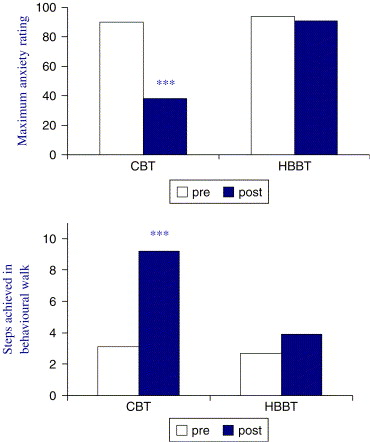

1. [Download : Download full-size image](https://ars.els-cdn.com/content/image/1-s2.0-S0005796706000507-gr1.jpg)

Fig. 1. (a/b). Behavioural walk: number of steps completed and the maximum anxiety experienced during the course of the test.

To obtain a clearer idea of the magnitude of the differences between CBT and HBET, controlled effects sizes were computed using the formula: controlled effect size=(HBET post-treatment mean minus CBT post-treatment mean)/pooled post-treatment standard deviation. Table 1 shows the results. For all the anxiety measures, the effect sizes were large (range 1.7–2.7).

### Depression

In contrast to the anxiety measures, analysis of the BDI revealed a significant effect of time but not a significant time×treatment interaction. Both treatments were associated with a significant pre-treatment to post treatment reduction in depression, perhaps because both were effective in reducing secondary demoralization.

## Discussion

The study reported here set out to evaluate the clinical effectiveness of identical levels of situational exposure which was presented and implemented in different ways. Therapy was significantly less effective on measures specific to anxiety, panic and avoidance when it emphasized the importance of prolonged exposure to feared situations and the habituation which would occur as opposed to treatment which helped the patients to disconfirm specific catastrophic beliefs identified as occurring in panic and drop or reverse the safety-seeking behaviours which they normally used in such situations.

The other issue concerns the role of the therapists involved, who were not blind either to condition or experimental hypothesis. It could be argued that the substantial differences seen may have been partly a result of therapist expectancies. The fact that ratings of patient expectancies rated after the rationale had been delivered were comparable suggests that therapists had presented treatments in a similarly convincing manner. We used two therapists throughout the treatment in an attempt to ensure the best possible adherence to the protocols throughout the intervention. All therapists involved in the study had experience of working in both cognitive-behavioural and behavioural modalities. However, the best way to address this issue would be a properly conducted independent replication.

Although it seems clear that belief disconfirmation-based exposure is an efficient treatment, the reason why it was superior to the habituation-based exposure treatment has not been established. CBT differed from HBET in two respects. The rationales were different and so were the instructions with respect to safety behaviours. Cognitive theory would imply that the difference in rationale and the difference in terms of whether safety behaviours are dropped (CBT) or maintained (HBET) are both important. However, it is logically possible that only the rationale or only the safety behaviours manipulation made the difference. In addition, when considering safety-seeking behaviours, a recent study in claustrophobia by Telch's group (Powers, Smits, & Telch, 2004) has suggested that whether a patient sees a safety behaviour as available may be as important as whether the safety behaviour is actually used. Exposure alone was compared with exposure plus using safety behaviours and with exposure plus having safety behaviours available. Having safety behaviours available retarded the effects of exposure as much as actually using the behaviours. Clearly, further research is required to disentangle the relative effects of exposure rationale, safety behaviour use and safety behaviour availability in modulating the effects of situational exposure in panic disorder with severe agoraphobia.

There are no previous panic disorder and agoraphobia studies that involved the comparison used in the present study. There are, however, a number of studies that compared the impact of mainly verbal cognitive therapy added to exposure with exposure alone (e.g. Burke, Drummond, & Johnston, 1997; e.g. Ost, Thulin, & Ramnero, 2004). Results of such studies have been substantially negative. Ost et al. (2004) suggested that the development of treatments which extend the experimental work on safety-seeking behaviours in agoraphobic situations (Salkovskis et al., 1999) are the next step, and have the potential to “push the proportion of clinically significant improvement into the same range as has been obtained for PD, 85–90%”. The large effect sizes observed with the CBT condition in the present study, which are comparable to those obtained by panic focused cognitive therapy in patients with milder agoraphobia in our earlier trials (Clark et al. (1994), Clark et al. (1999)) are consistent with Ost et al.'s (2004) suggestion. However, the present study involves small sample sizes and clearly needs replicating in a larger controlled trial.

## References

**American Psychiatric Association (1987)**

American Psychiatric Association

**Diagnostic and statistical manual of mental disorders**

(3rd revised ed), American Psychiatric Association, Washington, DC (1987)

[Google Scholar](https://scholar.google.com/scholar_lookup?title=Diagnostic%20and%20statistical%20manual%20of%20mental%20disorders&publication_year=1987&author=American%20Psychiatric%20Association)

**Beck, Epstein, Brown, & Steer (1988)**

A.T. Beck, N. Epstein, G. Brown, R.A. Steer

**An inventory for measuring clinical anxiety: Psychometric properties**

Journal of Consulting and Clinical Psychology, 56 (1988), pp. 893-897

[View Record in Scopus](https://www.scopus.com/inward/record.url?eid=2-s2.0-0024245652&partnerID=10&rel=R3.0.0)Google Scholar

**Beck, Ward, Mendelsohn, Mock, & Erbaugh (1961)**

A.T. Beck, C.H. Ward, M. Mendelsohn, J. Mock, J. Erbaugh

**An inventory for measuring depression**

Archives of General Psychiatry, 18 (1961), pp. 561-571

[CrossRef](https://doi.org/10.1001/archpsyc.1961.01710120031004)Google Scholar

**Burke, Drummond, & Johnston (1997)**

M. Burke, L.M. Drummond, D.W. Johnston

**Treatment choice for agoraphobic women: Exposure or cognitive-behaviour therapy?**

British Journal of Clinical Psychology, 36 (Pt 3) (1997), pp. 409-420

[CrossRef](https://doi.org/10.1111/j.2044-8260.1997.tb01248.x)[View Record in Scopus](https://www.scopus.com/inward/record.url?eid=2-s2.0-0030921738&partnerID=10&rel=R3.0.0)[Google Scholar](https://scholar.google.com/scholar?q=Treatment%20choice%20for%20agoraphobic%20women:%20Exposure%20or%20cognitive-behaviour%20therapy)

**Clark (1986)**

D.M. Clark

**A cognitive approach to panic**

Behaviour Research and Therapy, 24 (1986), pp. 461-470

[Article](https://www.sciencedirect.com/science/article/pii/0005796786900112)[Download PDF](https://www.sciencedirect.com/science/article/pii/0005796786900112/pdf?md5=64aef906ddc266008a071dd20ff4968e&pid=1-s2.0-0005796786900112-main.pdf)[View Record in Scopus](https://www.scopus.com/inward/record.url?eid=2-s2.0-0022606105&partnerID=10&rel=R3.0.0)[Google Scholar](https://scholar.google.com/scholar_lookup?title=A%20cognitive%20approach%20to%20panic&publication_year=1986&author=D.M.%20Clark)

**Clark (1989)**

D.M. Clark

**Anxiety states: Panic and generalised anxiety**

K. Hawton, P.M. Salkovskis, J. Kirk, D.M. Clark (Eds.), Cognitive therapy for psychiatric problems: A practical guide, Oxford University Press, Oxford (1989), pp. 52-96

[CrossRef](https://doi.org/10.1093/med:psych/9780192615879.003.0003)[Google Scholar](https://scholar.google.com/scholar_lookup?title=Anxiety%20states%3A%20Panic%20and%20generalised%20anxiety&publication_year=1989&author=D.M.%20Clark)

**Clark (1996)**

D.M. Clark

**Panic disorder: From theory to therapy**

P.M. Salkovskis (Ed.), Frontiers of cognitive therapy, Guilford, New York (1996)

[Google Scholar](https://scholar.google.com/scholar_lookup?title=Panic%20disorder%3A%20From%20theory%20to%20therapy&publication_year=1996&author=D.M.%20Clark)

**Clark (1999)**

D.M. Clark

**Anxiety disorders: Why they persist and how to treat them**

Behaviour Research and Therapy, 37 (S1) (1999), pp. s5-s28

[Google Scholar](https://scholar.google.com/scholar_lookup?title=Anxiety%20disorders%3A%20Why%20they%20persist%20and%20how%20to%20treat%20them&publication_year=1999&author=D.M.%20Clark)

**Clark et al. (1994)**

D.M. Clark, P.M. Salkovskis, A. Hackmann, H. Middleton, P. Anastasiades, M. Gelder

**A comparison of cognitive therapy, applied relaxation and imipramine in the treatment of panic disorder**

British Journal of Psychiatry, 164 (6) (1994), pp. 759-769

[CrossRef](https://doi.org/10.1192/bjp.164.6.759)[View Record in Scopus](https://www.scopus.com/inward/record.url?eid=2-s2.0-0028283050&partnerID=10&rel=R3.0.0)Google Scholar

**Clark et al. (1999)**

D.M. Clark, P.M. Salkovskis, A. Hackmann, A. Wells, J. Ludgate, M. Gelder

**Brief cognitive therapy for panic disorder: A randomized controlled trial**

Journal of Consulting and Clinical Psychology, 67 (4) (1999), pp. 583-589

[View Record in Scopus](https://www.scopus.com/inward/record.url?eid=2-s2.0-0032811491&partnerID=10&rel=R3.0.0)Google Scholar

**Craske, DeCola, Sachs, & Pontillo (2003)**

M.G. Craske, J.P. DeCola, A.D. Sachs, D.C. Pontillo

**Panic control treatment for agoraphobia**

Journal of Anxiety Disorders, 17 (3) (2003), pp. 321-333

[Article](https://www.sciencedirect.com/science/article/pii/S0887618502002037)[Download PDF](https://www.sciencedirect.com/science/article/pii/S0887618502002037/pdfft?md5=78854cd152ec5ded4c8b7f9cae5dd4d8&pid=1-s2.0-S0887618502002037-main.pdf)[View Record in Scopus](https://www.scopus.com/inward/record.url?eid=2-s2.0-0344088499&partnerID=10&rel=R3.0.0)[Google Scholar](https://scholar.google.com/scholar_lookup?title=Panic%20control%20treatment%20for%20agoraphobia&publication_year=2003&author=M.G.%20Craske&author=J.P.%20DeCola&author=A.D.%20Sachs&author=D.C.%20Pontillo)

**Hoffart (1995)**

A. Hoffart

**A comparison of cognitive and guided mastery therapy of agoraphobia**

Behaviour Research and Therapy, 33 (1995), pp. 423-434

[Article](https://www.sciencedirect.com/science/article/pii/000579679400056P)[Download PDF](https://www.sciencedirect.com/science/article/pii/000579679400056P/pdf?md5=e2e8fb34d0e168cb19d6af6ed48dee61&pid=1-s2.0-000579679400056P-main.pdf)[View Record in Scopus](https://www.scopus.com/inward/record.url?eid=2-s2.0-0028964516&partnerID=10&rel=R3.0.0)[Google Scholar](https://scholar.google.com/scholar_lookup?title=A%20comparison%20of%20cognitive%20and%20guided%20mastery%20therapy%20of%20agoraphobia&publication_year=1995&author=A.%20Hoffart)

**Mathews, Gelder, & Johnston (1981)**

A.M. Mathews, M.G. Gelder, D.W. Johnston

**Agoraphobia: Nature and treatment**

Guilford Press, New York (1981)

[Google Scholar](https://scholar.google.com/scholar_lookup?title=Agoraphobia%3A%20Nature%20and%20treatment&publication_year=1981&author=A.M.%20Mathews&author=M.G.%20Gelder&author=D.W.%20Johnston)

**Michelson, Marchione, & Greenwald (1996)**

L. Michelson, K. Marchione, S. Greenwald

**A comparative outcome and follow-up investigation of panic disorder with agoraphobia: The relative and combined efficacy of cognitive therapy, relaxation training, and therapist-assisted exposure**

Journal of Anxiety Disorders, 10 (5) (1996), pp. 297-330

[Article](https://www.sciencedirect.com/science/article/pii/0887618596000011)[Download PDF](https://www.sciencedirect.com/science/article/pii/0887618596000011/pdf?md5=d8323e507a28e1b5113306fd0ad3f970&pid=1-s2.0-0887618596000011-main.pdf)[View Record in Scopus](https://www.scopus.com/inward/record.url?eid=2-s2.0-0030248094&partnerID=10&rel=R3.0.0)Google Scholar

**Michelson, Marchione, & Mavissakalian (1985)**

L. Michelson, K. Marchione, M. Mavissakalian

**Cognitive and behavioural treatments of agoraphobia: Clinical, behavioural and psychophysiological outcome**

Journal of Consulting and Clinical Psychology, 53 (1985), pp. 913-926

[View Record in Scopus](https://www.scopus.com/inward/record.url?eid=2-s2.0-0022358774&partnerID=10&rel=R3.0.0)Google Scholar

**Ost, Thulin, & Ramnero (2004)**

L.G. Ost, U. Thulin, J. Ramnero

**Cognitive behavior therapy vs exposure in vivo in the treatment of panic disorder with agoraphobia (corrected from agrophobia)**

Behaviour Research and Therapy, 42 (10) (2004), pp. 1105-1127

[Article](https://www.sciencedirect.com/science/article/pii/S0005796703002110)[Download PDF](https://www.sciencedirect.com/science/article/pii/S0005796703002110/pdfft?md5=c2ea381f0c791714875955faaf1f2384&pid=1-s2.0-S0005796703002110-main.pdf)[View Record in Scopus](https://www.scopus.com/inward/record.url?eid=2-s2.0-4444306228&partnerID=10&rel=R3.0.0)[Google Scholar](https://scholar.google.com/scholar?q=Cognitive%20behavior%20therapy%20vs%20exposure%20in%20vivo%20in%20the%20treatment%20of%20panic%20disorder%20with%20agoraphobia)

**Powers, Smits, & Telch (2004)**

M.B. Powers, J.A. Smits, M.J. Telch

**Disentangling the effects of safety-behavior utilization and safety-behavior availability during exposure-based treatment: A placebo-controlled trial**

Journal of Consulting and Clinical Psychology, 72 (3) (2004), pp. 448-454

[View Record in Scopus](https://www.scopus.com/inward/record.url?eid=2-s2.0-2542468777&partnerID=10&rel=R3.0.0)Google Scholar

**Salkovskis (1991)**

P.M. Salkovskis

**The importance of behaviour in the maintenance of anxiety and panic: A cognitive account**

Behavioural Psychotherapy, 19 (1) (1991), pp. 6-19

[View Record in Scopus](https://www.scopus.com/inward/record.url?eid=2-s2.0-0026034196&partnerID=10&rel=R3.0.0)Google Scholar

**Salkovskis & Clark (1991)**

P.M. Salkovskis, D.M. Clark

**Cognitive therapy for panic attacks**

Journal of Cognitive Psychotherapy, 5 (3) (1991), pp. 215-226

[CrossRef](https://doi.org/10.1891/0889-8391.5.3.215)[View Record in Scopus](https://www.scopus.com/inward/record.url?eid=2-s2.0-0026314959&partnerID=10&rel=R3.0.0)[Google Scholar](https://scholar.google.com/scholar_lookup?title=Cognitive%20therapy%20for%20panic%20attacks&publication_year=1991&author=P.M.%20Salkovskis&author=D.M.%20Clark)

**Salkovskis, Clark, & Gelder (1996)**

P.M. Salkovskis, D.M. Clark, M.G. Gelder

**Cognition-behaviour links in the persistence of panic**

Behaviour Research and Therapy, 34 (5–6) (1996), pp. 453-458

[Article](https://www.sciencedirect.com/science/article/pii/0005796795000836)[Download PDF](https://www.sciencedirect.com/science/article/pii/0005796795000836/pdf?md5=46c669e19a8f99b8d037be9b6d47208e&pid=1-s2.0-0005796795000836-main.pdf)[View Record in Scopus](https://www.scopus.com/inward/record.url?eid=2-s2.0-0029932890&partnerID=10&rel=R3.0.0)[Google Scholar](https://scholar.google.com/scholar_lookup?title=Cognition-behaviour%20links%20in%20the%20persistence%20of%20panic&publication_year=1996&author=P.M.%20Salkovskis&author=D.M.%20Clark&author=M.G.%20Gelder)

**Salkovskis, Clark, Hackmann, Wells, & Gelder (1999)**

P.M. Salkovskis, D.M. Clark, A. Hackmann, A. Wells, M.G. Gelder

**An experimental investigation of the role of safety-seeking behaviours in the maintenance of panic disorder with agoraphobia**

Behaviour Research and Therapy, 37 (6) (1999), pp. 559-574

[Article](https://www.sciencedirect.com/science/article/pii/S0005796798001533)[Download PDF](https://www.sciencedirect.com/science/article/pii/S0005796798001533/pdfft?md5=83387be890e92502eb698f1e00eb6f2a&pid=1-s2.0-S0005796798001533-main.pdf)[View Record in Scopus](https://www.scopus.com/inward/record.url?eid=2-s2.0-0032906944&partnerID=10&rel=R3.0.0)Google Scholar

**Spitzer & Williams (1986)**

R.L. Spitzer, J.B. Williams

**Structured clinical interview for DSM IIIR**

New York State Psychiatric Institute, New York (1986)

[Google Scholar](https://scholar.google.com/scholar_lookup?title=Structured%20clinical%20interview%20for%20DSM%20IIIR&publication_year=1986&author=R.L.%20Spitzer&author=J.B.%20Williams)

**Wells, Clark, Salkovskis, & Ludgate et al. (1995)**

A. Wells, D.M. Clark, P. Salkovskis, J. Ludgate, *et al.*

**Social phobia: The role of in-situation safety behaviors in maintaining anxiety and negative beliefs**

Behaviour Therapy, 26 (1995), pp. 153-161

[Article](https://www.sciencedirect.com/science/article/pii/S0005789405800887)[Download PDF](https://www.sciencedirect.com/science/article/pii/S0005789405800887/pdf?md5=b9bb07818e69a497c852335e64eee3e0&pid=1-s2.0-S0005789405800887-main.pdf)[View Record in Scopus](https://www.scopus.com/inward/record.url?eid=2-s2.0-0028965132&partnerID=10&rel=R3.0.0)Google Scholar

**Williams & Falbo (1996)**

S.L. Williams, J. Falbo

**Cognitive and performance-based treatments for panic attacks in people with varying degrees of agoraphobic disability**

Behaviour Research and Therapy, 34 (3) (1996), pp. 253-264

[Article](https://www.sciencedirect.com/science/article/pii/0005796795000631)[Download PDF](https://www.sciencedirect.com/science/article/pii/0005796795000631/pdf?md5=5e2d962902a84b794c876770c1d163c1&pid=1-s2.0-0005796795000631-main.pdf)[View Record in Scopus](https://www.scopus.com/inward/record.url?eid=2-s2.0-0029989594&partnerID=10&rel=R3.0.0)Google Scholar

### Emotional self-regulation, virtual reality and neurofeedback

- 2021, Computers in Human Behavior Reports

### Exposure therapy vs lifestyle intervention to reduce food cue reactivity and binge eating in obesity: A pilot study

- 2020, Journal of Behavior Therapy and Experimental Psychiatry

  Citation Excerpt :

### The temporal course of over-generalized conditioned threat expectancies in posttraumatic stress disorder

- 2020, Behaviour Research and Therapy

### The unique and conditional effects of interoceptive exposure in the treatment of anxiety: A functional analysis

- 2019, Behaviour Research and Therapy

### Behavioral Experiments for Intolerance of Uncertainty: Challenging the Unknown in the Treatment of Generalized Anxiety Disorder

- 2019, Cognitive and Behavioral Practice

### Dropping Safety Aids and Maximizing Retrieval Cues: Two Keys to Optimizing Inhibitory Learning During Exposure Therapy

- 2019, Cognitive and Behavioral Practice

Copyright © 2006 Elsevier Ltd. All rights reserved.

### A systematic review of predictors and moderators of improvement in cognitive-behavioral therapy for panic disorder and agoraphobia

[figure not shown]